# Data Camp / ARIMA Modeling with R - Chapter 4

Initialize and load the data

```r
library(astsa)
library(xts)
```

Chapter 4 of [Data Camp - ARIMA Modeling with R](https://www.datacamp.com/courses/arima-modeling-with-r)

## Seasonal ARIMA models

The letter s denotes the seasonal period. i.e. 4 quarters, 12 months, 1.203849928849390 nano-seconds.

### Pure Seasonal Models

consider pure seasonal models such as an $SAR(P=1)_{1=12}$ model. This would be something like monthly temperatures where the temperature for the current period is dependant on the one from 12 months prior + some noise.

$X_t = \phi X_{t-12} + W_t$

### ACF and PACF of Pure Seasonal Models

ACF and PACF behave as they do with the non-seasonal but only at the seasonal points, i.e. for S=4, 0, 4, 8, 12, … or for s=12, 0, 12, 24, …

| $SAR(P)_s$ | $SMA(Q)_s$ | $SARMA(P,Q)_s$ |  |
| --- | --- | --- | --- |
| ACF* | Tails off | Cuts off lag QS | Tails off |
| PACF* | Cuts off lag PS | Tails off | Tails off |

- The values at the nonseasonal lags are 0

### Mixed Seasonal Model

These are called: $\text{SARIMA}(p,d,q) x (P,D,Q)_s$ models.

The **p,d,q** are the orders of the non-seasonal part of the model and the upper case letters the seasonal part.

Consider $SARIMA(0,0,1)x(1,0,0)_12$ - $X_t = \phi X_{t-12} + W_t + \theta W_{t-1}$

This model says this months value is dependant on

- **SAR(1)**: The value from 12 periods ago $X_{t-12}$
- **MA(1)**: The *shock* (error) from the previos period. $W_{t-1}$

## Determining what type of Mixed Model.

Looking at the P/ACF

1. Focus first on the seasonal part (lags 12, 24, …) to see what the P/ACF values are doing to determine the model(s) to try.
2. Then focus on the non-seasonal part (lags 1, 2, 3, …) to determine the best model to choose.

## Analysis of AirPassengers

- Data has trend and non-linear growth, that is the variance is increasing..
- log the data, which removes the non-linear growth and controls the values
- diff the data to remove the trend.

Note that there is what appears to be seasonality every 12 periods (months), this can be removed with a call to `diff(d, lag=12)` which will diff the data with lag=12.

- diff the data with lag=12 to remove the 12 period seasonality.

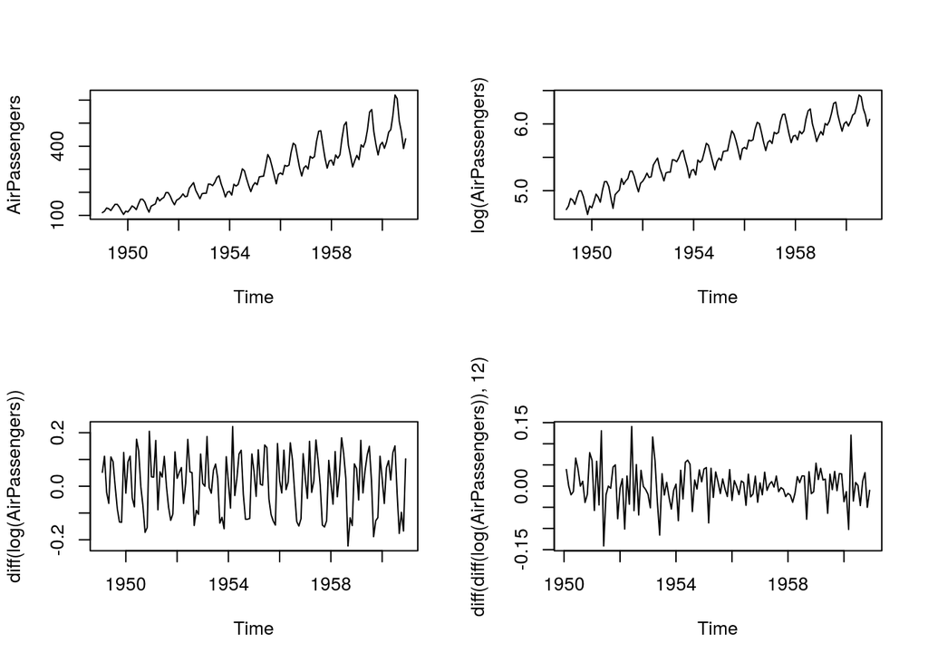

```r
par(mfrow=c(2,2))
plot(AirPassengers)
plot(log(AirPassengers))
plot(diff(log(AirPassengers)))
plot(diff(diff(log(AirPassengers)),12))
```

At thsi point we have d=1, D=1 and S=12.

Apply P/ACF the diffed data. max.lag=48 for 48 periods (4 years)

ACF appears to cut off at s = 12 adn PACF appears to be trailing off which suggests a SMA, so P=0 and Q=1.

ACF and PACF appear to be trailing off which implies an arma so p=1 q=1

So we conclude an SARIMA(1,1,1)(0,1,1) on the log data. However, the sarima shows no significance for the ar1 component, so we adjust the model to SARIMA(0,1,1)(0,1,1)

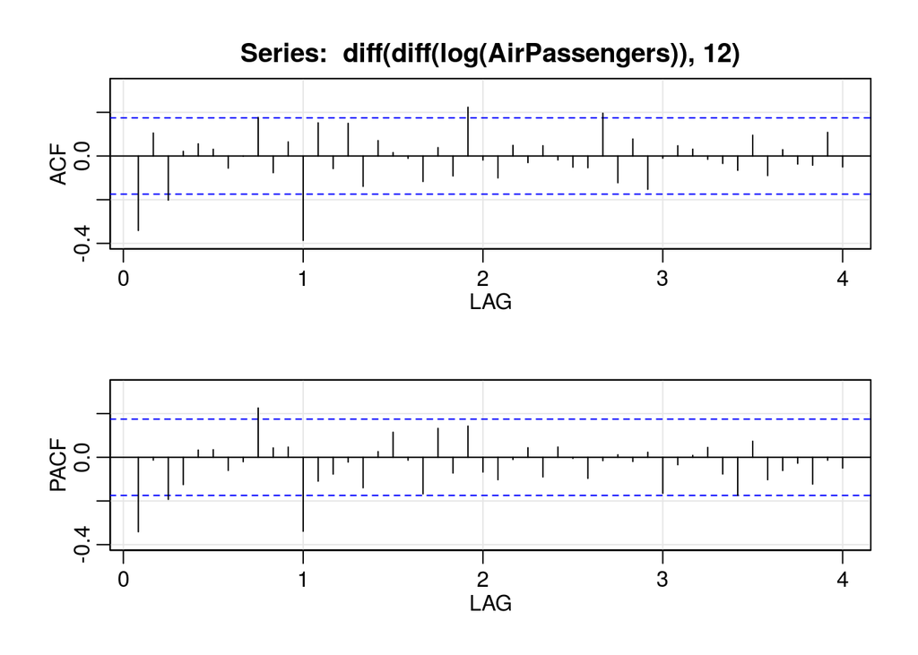

```
##         ACF  PACF
##  [1,] -0.34 -0.34
##  [2,]  0.11 -0.01
##  [3,] -0.20 -0.19
##  [4,]  0.02 -0.13
##  [5,]  0.06  0.03
##  [6,]  0.03  0.03
##  [7,] -0.06 -0.06
##  [8,]  0.00 -0.02
##  [9,]  0.18  0.23
## [10,] -0.08  0.04
## [11,]  0.06  0.05
## [12,] -0.39 -0.34
## [13,]  0.15 -0.11
## [14,] -0.06 -0.08
```

[output cut: 34 more lines]

```r
acf2(diff(diff(log(AirPassengers)),12), max.lag = 48)
```

```r
fit = sarima(log(AirPassengers), 1, 1, 1, 0, 1, 1, 12)
```

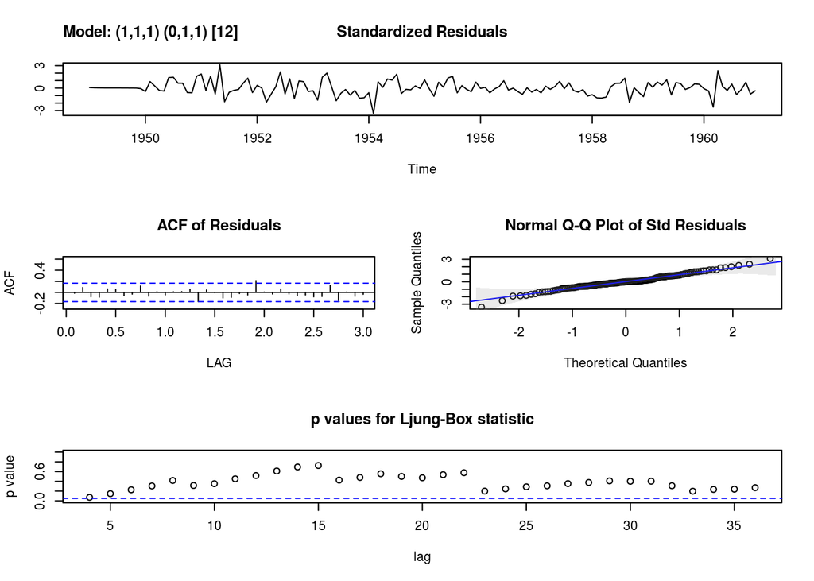

```r
fit$ttable
```

```
##      Estimate     SE t.value p.value
## ar1    0.1960 0.2475  0.7921  0.4297
## ma1   -0.5784 0.2132 -2.7127  0.0075
## sma1  -0.5643 0.0747 -7.5544  0.0000
```

```r
fit1 = sarima(log(AirPassengers), 0, 1, 1, 0, 1, 1, 12)
```

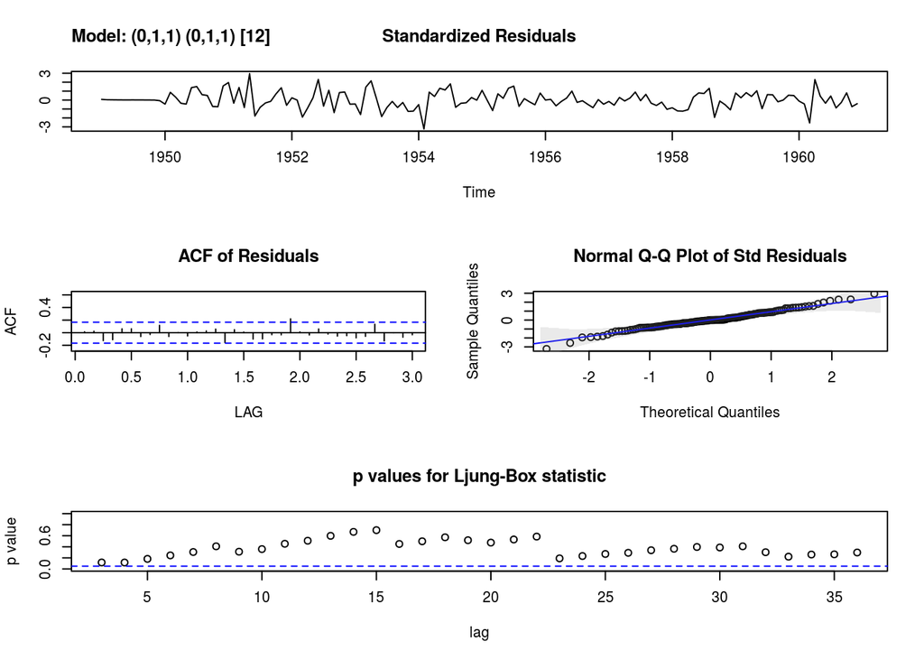

```r
fit1$ttable
```

```
##      Estimate     SE t.value p.value
## ma1   -0.4018 0.0896 -4.4825       0
## sma1  -0.5569 0.0731 -7.6190       0
```

## Let’s do it again with seasonal unemployment

Data appears to have a trend. Difference the data to remove the trend.

Data appears to have seasonality. Difference again with lag=12 (we could look closely to see this and it’s there.)

Finally, no trend or seasonality, just WN.

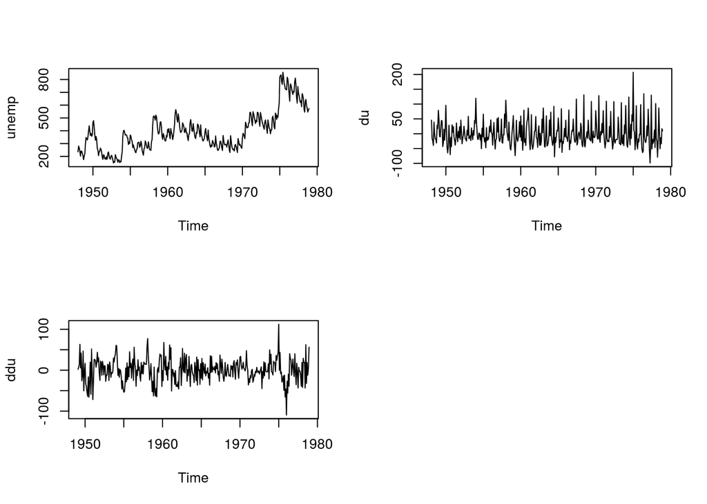

```r
par(mfrow=c(2,2))
plot(unemp)
du <- diff(unemp)
plot(du)
ddu <- diff(du, lag=12)
plot(ddu)
```

## P/ACF the ddu data

Set lag to 60 for 5 years.

ACF at seasonal intervals drops off and PACF tails off, so SMA(1)

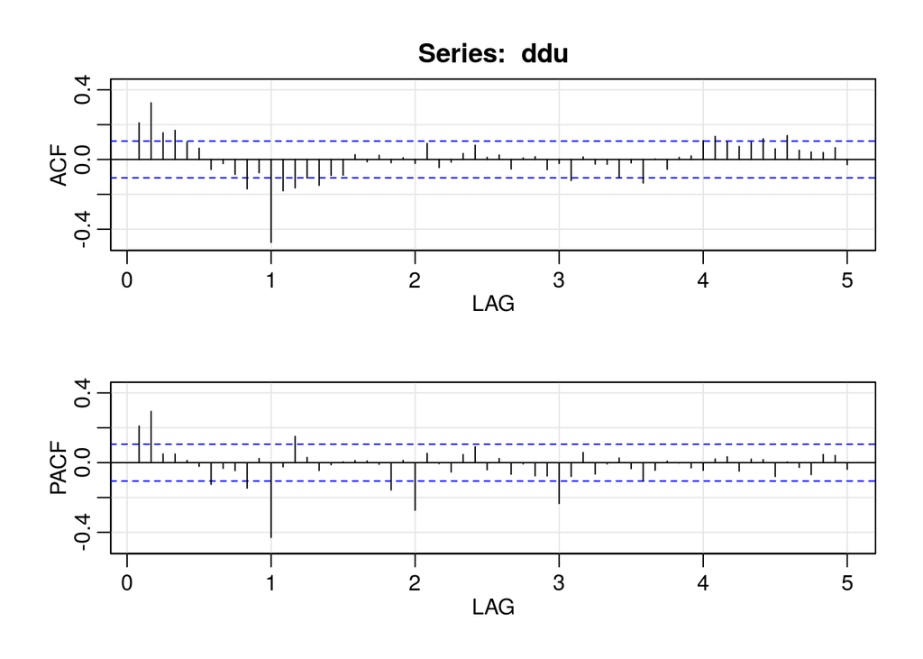

```
##         ACF  PACF
##  [1,]  0.21  0.21
##  [2,]  0.33  0.29
##  [3,]  0.15  0.05
##  [4,]  0.17  0.05
##  [5,]  0.10  0.01
##  [6,]  0.06 -0.02
##  [7,] -0.06 -0.12
##  [8,] -0.02 -0.03
##  [9,] -0.09 -0.05
## [10,] -0.17 -0.15
## [11,] -0.08  0.02
## [12,] -0.48 -0.43
## [13,] -0.18 -0.02
## [14,] -0.16  0.15
```

[output cut: 46 more lines]

```r
acf2(ddu, max.lag=60)
```

And *BAM!* well fitting model! Me know something!

```r
fit = sarima(unemp, 2, 1, 0, 0, 1, 1, 12)
```

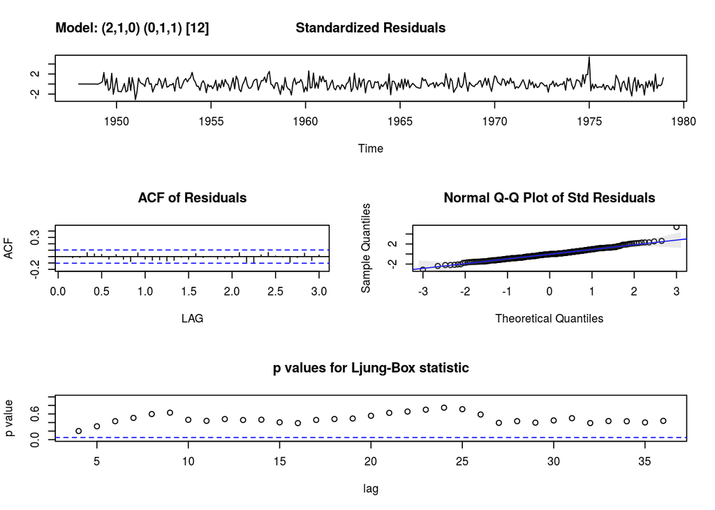

```r
fit$ttable
```

```
##      Estimate     SE  t.value p.value
## ar1    0.1351 0.0513   2.6326  0.0088
## ar2    0.2464 0.0515   4.7795  0.0000
## sma1  -0.6953 0.0381 -18.2362  0.0000
```

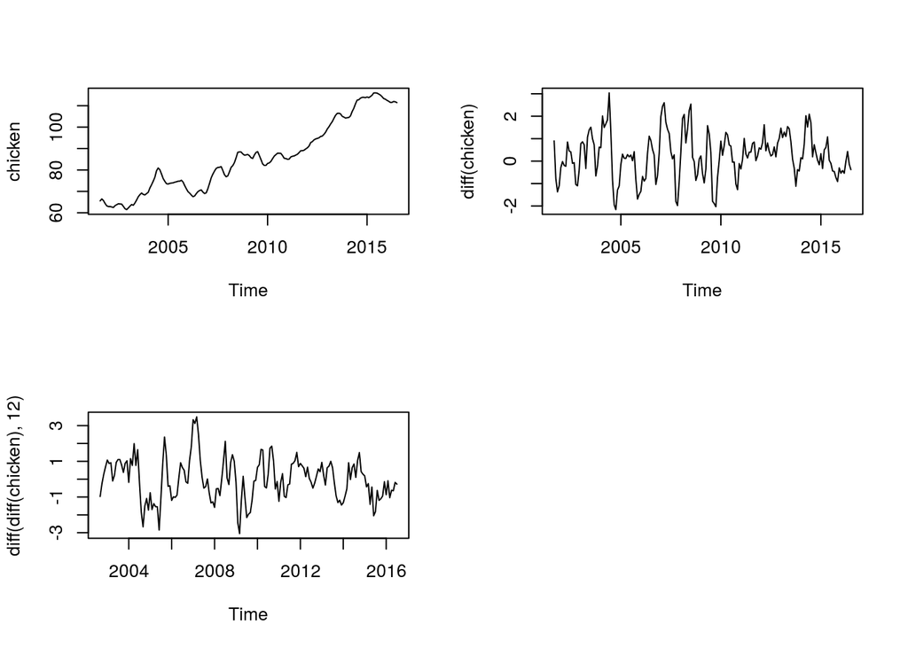

```r
par(mfrow=c(2,2))

plot(chicken)
plot(diff(chicken))
plot(diff(diff(chicken), 12))
```

There is seasonal persistence, the fact that the ACF values at seasonal intervals persists. So, you need to difference it again.

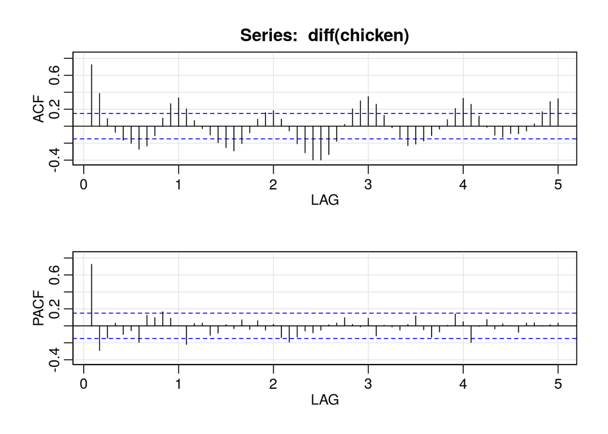

```
##         ACF  PACF
##  [1,]  0.72  0.72
##  [2,]  0.39 -0.29
##  [3,]  0.09 -0.14
##  [4,] -0.07  0.03
##  [5,] -0.16 -0.10
##  [6,] -0.20 -0.06
##  [7,] -0.27 -0.19
##  [8,] -0.23  0.12
##  [9,] -0.11  0.10
## [10,]  0.09  0.16
## [11,]  0.26  0.09
## [12,]  0.33  0.00
## [13,]  0.20 -0.22
## [14,]  0.07  0.03
```

[output cut: 46 more lines]

```r
acf2(diff(chicken), max.lag=60)
```

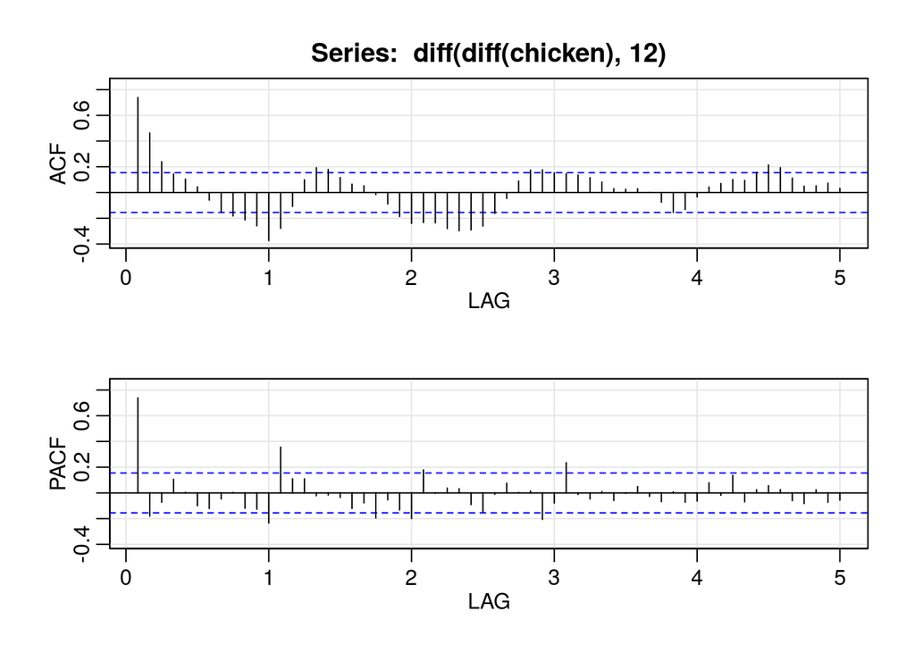

```
##         ACF  PACF
##  [1,]  0.74  0.74
##  [2,]  0.46 -0.18
##  [3,]  0.24 -0.07
##  [4,]  0.14  0.11
##  [5,]  0.10  0.00
##  [6,]  0.04 -0.10
##  [7,] -0.06 -0.12
##  [8,] -0.15 -0.05
##  [9,] -0.18  0.00
## [10,] -0.21 -0.12
## [11,] -0.26 -0.13
## [12,] -0.37 -0.23
## [13,] -0.28  0.36
## [14,] -0.11  0.11
```

[output cut: 46 more lines]

```r
acf2(diff(diff(chicken), 12), max.lag=60)
```

## Births

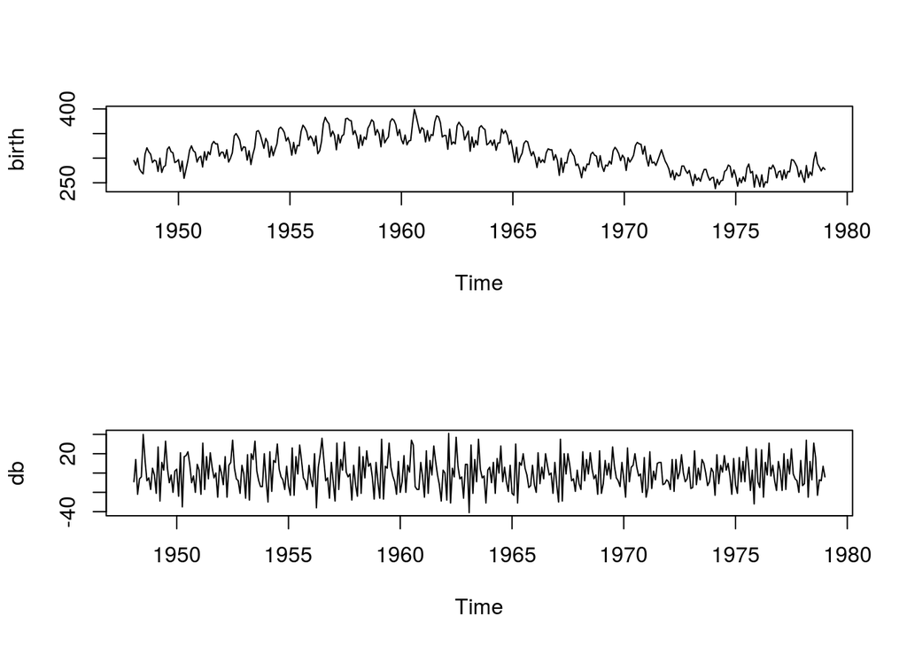

```r
par(mfrow=c(2,1))
plot(birth)
db = diff(birth)
plot(db)
```

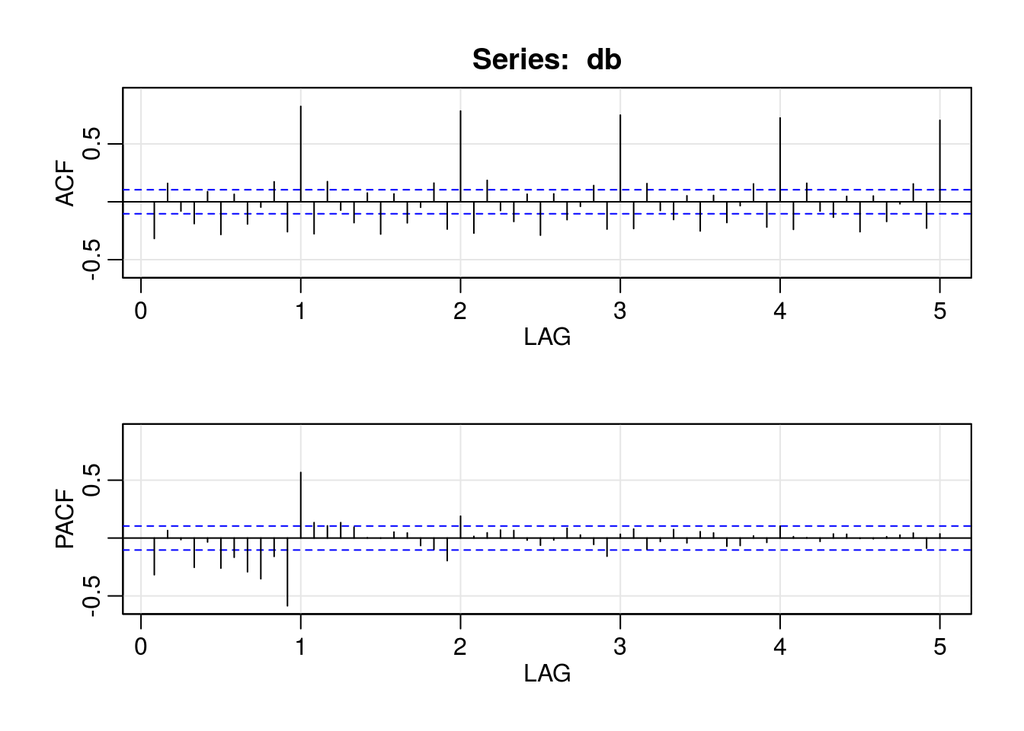

```
##         ACF  PACF
##  [1,] -0.32 -0.32
##  [2,]  0.16  0.06
##  [3,] -0.08 -0.01
##  [4,] -0.19 -0.25
##  [5,]  0.09 -0.03
##  [6,] -0.28 -0.26
##  [7,]  0.06 -0.17
##  [8,] -0.19 -0.29
##  [9,] -0.05 -0.35
## [10,]  0.17 -0.16
## [11,] -0.26 -0.59
## [12,]  0.82  0.57
## [13,] -0.28  0.13
## [14,]  0.17  0.11
```

[output cut: 46 more lines]

```r
acf2(db, max.lag = 60)
```

There is seasonal persistence, lines not going away at seasonal lags, so difference again but with lag=12.

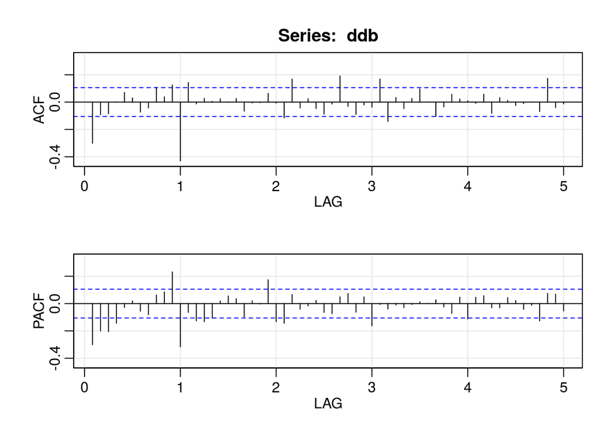

```
##         ACF  PACF
##  [1,] -0.30 -0.30
##  [2,] -0.09 -0.20
##  [3,] -0.09 -0.21
##  [4,]  0.00 -0.14
##  [5,]  0.07 -0.03
##  [6,]  0.03  0.02
##  [7,] -0.07 -0.06
##  [8,] -0.04 -0.08
##  [9,]  0.11  0.06
## [10,]  0.04  0.08
## [11,]  0.13  0.23
## [12,] -0.43 -0.32
## [13,]  0.14 -0.06
## [14,] -0.01 -0.13
```

[output cut: 46 more lines]

```r
ddb = diff(db, lag=12)
acf2(ddb, max.lag=60)
```

Seasonal ACF drops and PACF trails off at seasonal lag 1, so SMA(1).

ACF drops at lag=1 and PACF trails off at lag=1.

Had to diff 2 x so model is 0, 1, 1, 0, 1, 1, 12?

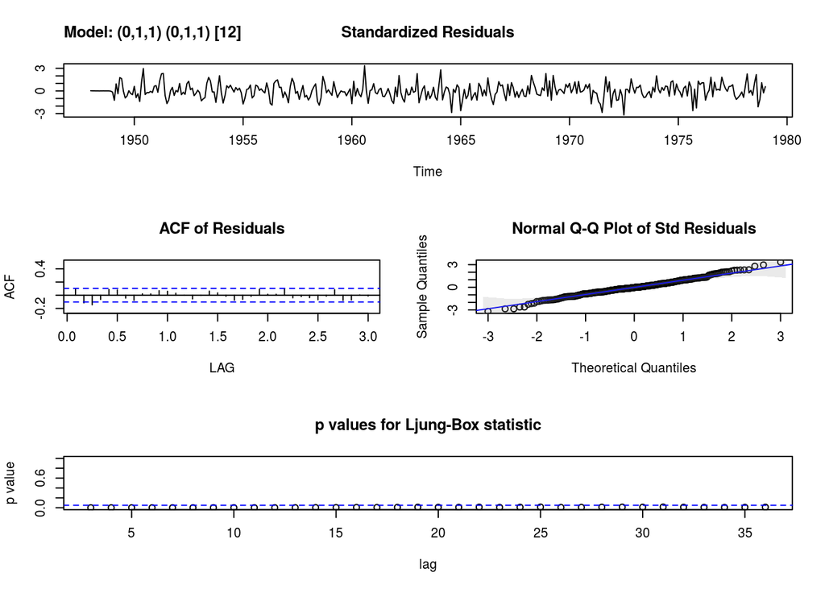

```
## $fit
##
## Call:
## stats::arima(x = xdata, order = c(p, d, q), seasonal = list(order = c(P, D,
##     Q), period = S), include.mean = !no.constant, optim.control = list(trace = trc,
##     REPORT = 1, reltol = tol))
##
## Coefficients:
##           ma1     sma1
##       -0.4734  -0.7861
## s.e.   0.0598   0.0451
##
## sigma^2 estimated as 47.4:  log likelihood = -1211.28,  aic = 2428.56
##
## $degrees_of_freedom
## [1] 371
##
## $ttable
##      Estimate     SE  t.value p.value
## ma1   -0.4734 0.0598  -7.9097       0
## sma1  -0.7861 0.0451 -17.4227       0
##
## $AIC
## [1] 4.869388
##
## $AICc
## [1] 4.874924
##
## $BIC
## [1] 3.890415
```

```r
sarima(birth, 0, 1, 1, 0, 1, 1, 12)
```

Residual analysis isn’t ideal. Perhaps the drop in ACF was a trail off, try adding an AR

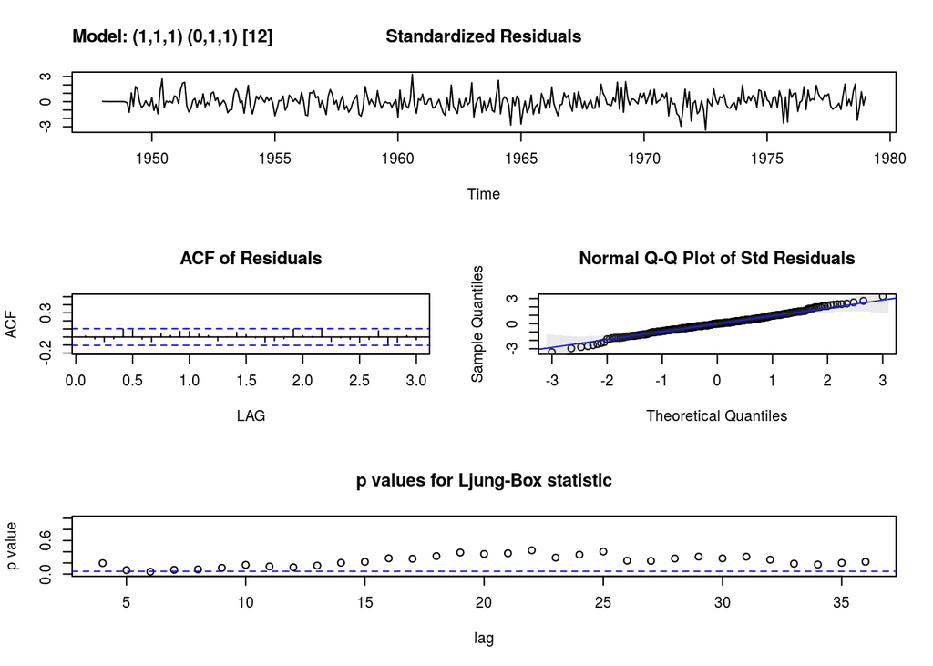

```
## $fit
##
## Call:
## stats::arima(x = xdata, order = c(p, d, q), seasonal = list(order = c(P, D,
##     Q), period = S), include.mean = !no.constant, optim.control = list(trace = trc,
##     REPORT = 1, reltol = tol))
##
## Coefficients:
##          ar1      ma1     sma1
##       0.3038  -0.7006  -0.8000
## s.e.  0.0865   0.0604   0.0441
##
## sigma^2 estimated as 45.91:  log likelihood = -1205.93,  aic = 2419.85
##
## $degrees_of_freedom
## [1] 370
##
## $ttable
##      Estimate     SE  t.value p.value
## ar1    0.3038 0.0865   3.5104   5e-04
## ma1   -0.7006 0.0604 -11.5984   0e+00
## sma1  -0.8000 0.0441 -18.1302   0e+00
##
## $AIC
## [1] 4.842869
##
## $AICc
## [1] 4.848523
##
## $BIC
## [1] 3.87441
```

```r
sarima(birth, 1, 1, 1, 0, 1, 1, 12)
```

AR coefficient is significant and residuals are looking better.

## Forecasting.

Like with simpla ARIMA forecasting is simple. **astsa** includes an `sarima.for()` function for forecasting seasona arimas.

Let’s use the unemployment example from previously. This was modeled as **SARIMA(2, 1, 0, 0, 1, 1, 12)**

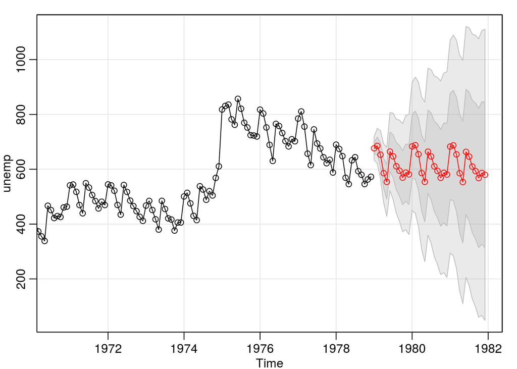

```
## $pred
##           Jan      Feb      Mar      Apr      May      Jun      Jul
## 1979 676.4664 685.1172 653.2388 585.6939 553.8813 664.4072 647.0657
## 1980 683.3045 687.7649 654.8658 586.1507 553.9285 664.1108 646.6220
## 1981 682.6406 687.0977 654.1968 585.4806 553.2579 663.4398 645.9508
##           Aug      Sep      Oct      Nov      Dec
## 1979 611.0828 594.6414 569.3997 587.5801 581.1833
## 1980 610.5345 594.0427 568.7684 586.9320 580.5249
## 1981 609.8632 593.3713 568.0970 586.2606 579.8535
##
## $se
##            Jan       Feb       Mar       Apr       May       Jun       Jul
## 1979  21.20465  32.07710  43.70167  53.66329  62.85364  71.12881  78.73590
## 1980 116.99599 124.17344 131.51281 138.60466 145.49706 152.12863 158.52302
## 1981 194.25167 201.10648 208.17066 215.11503 221.96039 228.64285 235.16874
##            Aug       Sep       Oct       Nov       Dec
## 1979  85.75096  92.28663  98.41329 104.19488 109.67935
## 1980 164.68623 170.63839 176.39520 181.97333 187.38718
## 1981 241.53258 247.74268 253.80549 259.72970 265.52323
```

```r
sarima.for(unemp, 2, 1, 0, 0, 1, 1, 12, n.ahead=36)
```

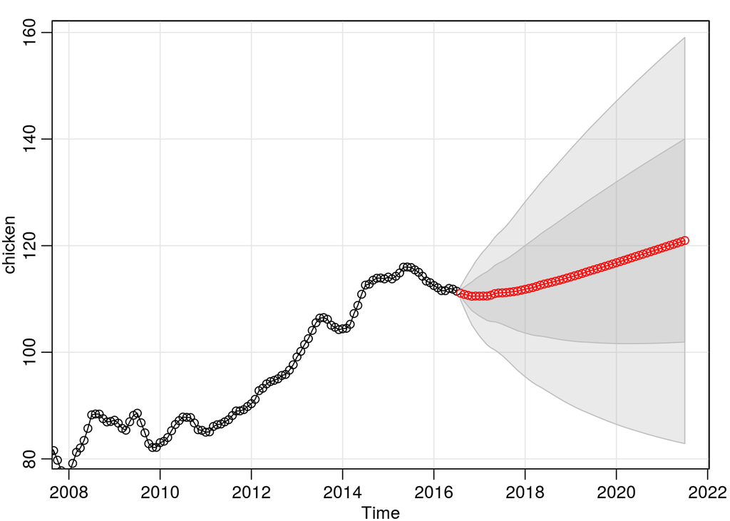

```
## $pred
##           Jan      Feb      Mar      Apr      May      Jun      Jul
## 2016
## 2017 110.5358 110.5612 110.5480 110.7055 111.0047 111.1189 111.1552
## 2018 111.8108 111.9782 112.1330 112.3431 112.5991 112.7952 112.9661
## 2019 114.1331 114.3464 114.5556 114.7827 115.0247 115.2473 115.4617
## 2020 116.7942 117.0224 117.2492 117.4819 117.7193 117.9505 118.1790
## 2021 119.5651 119.7980 120.0306 120.2650 120.5010 120.7350 120.9681
##           Aug      Sep      Oct      Nov      Dec
## 2016 111.0907 110.8740 110.6853 110.5045 110.5527
## 2017 111.1948 111.2838 111.3819 111.4825 111.6572
## 2018 113.1380 113.3260 113.5168 113.7085 113.9242
## 2019 115.6765 115.8965 116.1174 116.3386 116.5675
## 2020 118.4077 118.6380 118.8686 119.0993 119.3326
## 2021
##
## $se
##             Jan        Feb        Mar        Apr        May        Jun
## 2016
## 2017  3.7414959  4.1793190  4.5747009  4.9373266  5.2742129  5.5903499
## 2018  8.2010253  8.5605811  8.9054714  9.2372195  9.5572539  9.8667955
## 2019 12.0038164 12.2921541 12.5738417 12.8492868 13.1188976 13.3830477
## 2020 15.1557253 15.3959082 15.6323906 15.8653300 16.0948844 16.3212022
## 2021 17.8397890 18.0473081 18.2524651 18.4553364 18.6559977 18.8545213
##             Jul        Aug        Sep        Oct        Nov        Dec
## 2016             0.6187194  1.3368594  2.0462419  2.6867986  3.2486625
## 2017  5.8893133  6.2367345  6.6253573  7.0309771  7.4344077  7.8255932
## 2018 10.1668604 10.4736807 10.7857727 11.0980056 11.4063211 11.7085266
## 2019 13.6420693 13.9002670 14.1573839 14.4122197 14.6638269 14.9117124
## 2020 16.5444204 16.7657634 16.9852163 17.2025022 17.4174076 17.6298379
## 2021 19.0509752
```

```r
sarima.for(chicken, 2, 1, 0, 1, 0, 0, 12, n.ahead=60)
```